# Form Recognizer 서비스를 이용하여 영수증 분석

[figure not shown]

인공지능(AI) 컴퓨터 비전 분야에서 광학 문자 인식(OCR)은 일반적으로 인쇄된 문서나 손으로 쓴 문서를 읽는 데 사용된다. 종종, 텍스트는 추가 처리나 분석에 사용될 수 있는 형식으로 문서에서 간단히 추출된다.

In the artificial intelligence (AI) field of computer vision, optical character recognition (OCR) is commonly used to read printed or handwritten documents. Often, the text is simply extracted from the documents into a format that can be used for further processing or analysis.

보다 진보된 OCR 시나리오는 양식의 필드가 무엇을 나타내는지를 의미적으로 이해하면서 구매 주문서나 송장 같은 양식에서 정보를 추출하는 것이다. **양식 인식기** 서비스는 이러한 종류의 AI 문제를 위해 특별히 설계되었습니다.

A more advanced OCR scenario is the extraction of information from forms, such as purchase orders or invoices, with a semantic understanding of what the fields in the form represent. The **Form Recognizer** service is specifically designed for this kind of AI problem.

## 영수증 보기

이 예에서는 Form Recognizer'에 기본적으로 포함되어 있는 영수증 분석 모델을 사용할 것이다.

아래의 셀에 있는 **Run cell** (▷) 버튼(셀의 왼편에 있음)을 클릭하여 Form Recognizwer를 이용하여 영수증을 분석하는 예제를 살펴보자.

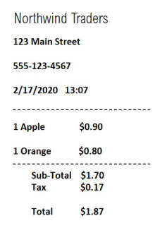

```python
import matplotlib.pyplot as plt
from PIL import Image
import os
%matplotlib inline


# 영수증 이미지를 로드해서 나타낸다.
fig = plt.figure(figsize=(6, 6))
image_path = os.path.join('data', 'form-receipt', 'receipt.jpg')
img = Image.open(image_path)
plt.axis('off')
plt.imshow(img)
```

## Form Recognizer 리소스 만들기

Azure 구독에서 Form Recognizer 리소스를 생성해보자:

1. 브라우저의 새로운 탭을 열고, Azure portal( https://portal.azure.com)을 입력하고 , Microsoft계정으로 로그인한다..
2. **＋리소스 만들기** 버튼을 클릭하고, *Form Recognizer* 서비스를 찾는다
3. 서비스 리스트에서 **Form Recognizer**를 찾는다.
4. **Form Recognizer**에서 **만들기**를 클릭한다.
5. **Form Recognizer 만들기**에서 아래의 내용을 입력하고 **만들기**를 클릭한다.
   - **이름**: *유일한 이름을 입력한다(가능하면 영문과 숫자사용)*.
   - **구독**: *Azure 구독선택*.
   - **위치**: *가능한 위치(한국 중부 추천)*:
   - **가격책정계층**: F0
   - **리소스 그룹**: *원하는 유리한 이름(가능하면 영문과 숫자사용)*
   - **검토 + 만들기**를 선택한다.
6. 만들기가 완료될 때까지 기다린다.
7. Azure Portal에서 Form Recognizer 서비스가 새롭게 생성된 것을 확인하고 **Keys and Endpoint** 페이지에서 **Key1**과 **엔드포인트**값을 복사하고 아래의 셀의 **YOUR_FORM_KEY**와 **YOUR_FORM_ENDPOINT**에 붙여 넣는다.

```python
form_key = 'YOUR_FORM_KEY'
form_endpoint = 'YOUR_FORM_ENDPOINT'

print('Ready to use form recognizer at {} using key {}'.format(form_endpoint, form_key))
```

Python에서 Form Recognizer리소스를 사용하기 위해서는 Azure Form Recognizer SDK를 설치할 필요가 있다.

```python
! pip install azure_ai_formrecognizer
```

## 영수증 분석하기

이제 Form Recognizre를 이용하여 영수증을 분석할 준비가 되었다.

```python
import os
from azure.ai.formrecognizer import FormRecognizerClient
from azure.core.credentials import AzureKeyCredential

# Form Recognizer 서비스를 위한 클라이언트를 만든다.
form_recognizer_client = FormRecognizerClient(endpoint=form_endpoint, credential=AzureKeyCredential(form_key))

try:
    print("Analyzing receipt...")
    # 이미지 파일에서 영수증을 가져온다
    image_path = os.path.join('data', 'form-receipt', 'receipt.jpg')

    # 파일 데이터를 Form Recognizer에 제출한다
    with open(image_path, "rb") as f:
        analyze_receipt = form_recognizer_client.begin_recognize_receipts(receipt=f)

    # 결과 가져오기
    receipt_data = analyze_receipt.result()

    # 첫번째(그리고 유일한) 영수증으로부터 추출된 데이터를 프린트한다.
    receipt = receipt_data[0]
    receipt_type = receipt.fields.get("ReceiptType")
    if receipt_type:
        print("Receipt Type: {}".format(receipt_type.value))
    merchant_address = receipt.fields.get("MerchantAddress")
    if merchant_address:
        print("Merchant Address: {}".format(merchant_address.value))
    merchant_phone = receipt.fields.get("MerchantPhoneNumber")
    if merchant_phone:
        print("Merchant Phone: {}".format(merchant_phone.value))
    transaction_date = receipt.fields.get("TransactionDate")
    if transaction_date:
        print("Transaction Date: {}".format(transaction_date.value))
    print("Receipt items:")
    items = receipt.fields.get("Items")
    if items:
        for idx, item in enumerate(receipt.fields.get("Items").value):
            print("\tItem #{}".format(idx+1))
            item_name = item.value.get("Name")
            if item_name:
                print("\t - Name: {}".format(item_name.value))
            item_total_price = item.value.get("TotalPrice")
            if item_total_price:
                print("\t - Price: {}".format(item_total_price.value))
    subtotal = receipt.fields.get("Subtotal")
    if subtotal:
        print("Subtotal: {} ".format(subtotal.value))
    tax = receipt.fields.get("Tax")
    if tax:
        print("Tax: {}".format(tax.value))
    total = receipt.fields.get("Total")
    if total:
        print("Total: {}".format(total.value))

except Exception as ex:
    print('Error:', ex)
```

[output not shown]

## 더많은 정보

Form Recognizer서비스에 대한 더 많은 정보는 다음을 참고하기 바란다. [Form Recognizer 문서](https://docs.microsoft.com/ko-kr/azure/cognitive-services/form-recognizer/index)